# Modules & Packages

[Modules](https://docs.python.org/3/tutorial/modules.html) are files (ending in .py) containing Python definitions (functions, classes) and statements. You can import modules into other modules, interactive sessions, notebooks, etc. It can be convenient to put your own custom functions into modules, and there are many useful, freely available modules written by others.

Packages are (roughly speaking) collections of modules.

A large number of packages and modules are installed with the Anaconda distribution that you downloaded. In particular, [SciPy](https://www.scipy.org/), [NumPy](http://www.numpy.org/), [Pandas](http://pandas.pydata.org/), and [Matplotlib](http://matplotlib.org/) all come with Anaconda. We will be using (bits and pieces) of these (and other packages) throughout the semester.

Anaconda also comes with a package manager called [Conda](https://conda.io/docs/), and Python comes with a package manager called [pip](https://pip.pypa.io/en/stable/). These links go to documentation for Conda and pip. We will talk about both at various points during the semester.

You can import a package (or a module) like this:

```python
import numpy
```

After doing this, everything inside NumPy is available as a method (or a method within a module nested inside NumPy, sometimes multiple layers down). For example, we can create a NumPy [`array`](https://docs.scipy.org/doc/numpy-1.13.0/reference/arrays.ndarray.html) (technically, an `ndarray`, for "n-dimensional array"). An `array` is a very useful, very frequently used data type for containing (typically) numerical data.

To create an `array`, we can call the function `array()` and give it a list of numbers as input:

```python
x = numpy.array([10,20,30,40,50])
type(x)
```

```
numpy.ndarray
```

```python
x
```

```
array([10, 20, 30, 40, 50])
```

Arrays support indexing and slicing just like lists and tuples:

```python
x[1]
```

```
20
```

```python
x[1:3]
```

```
array([20, 30])
```

You can change (typically to abbreviate) the name of an imported module by importing it `as` whatever name you prefer. The standard abbreviation for `numpy` is `np`:

```python
import numpy as np
y = np.array([30,40,50,60])
y
```

```
array([30, 40, 50, 60])
```

Note that when we `import` a module `as` something else, we use that new name to access its modules/methods/etc.

### Importing functions

If you just want a specific subset of the functions from a package or module, you can import those specific functions `from` that module or package. For example, we can import just the functions `array()` (creates an array), `zeros()` (creates an array filled with zeros), `ones()` (creates an array filled with ones), `arange()` (creates an array with a specified sequence of integers), and `linspace()` (creates an array with equally spaced numbers over a specified range):

```python
from numpy import array, zeros, ones, arange, linspace
%whos
```

```
Variable   Type                          Data/Info
--------------------------------------------------
arange     builtin_function_or_method    <built-in function arange>
array      builtin_function_or_method    <built-in function array>
linspace   function                      <function linspace at 0x10400d378>
np         module                        <module 'numpy' from '/Us<...>kages/numpy/__init__.py'>
numpy      module                        <module 'numpy' from '/Us<...>kages/numpy/__init__.py'>
ones       function                      <function ones at 0x103fbb488>
x          ndarray                       5: 5 elems, type `int64`, 40 bytes
y          ndarray                       4: 4 elems, type `int64`, 32 bytes
zeros      builtin_function_or_method    <built-in function zeros>
```

Now we can use these functions without prepending `np`.

The function `zeros()` creates an array of zeros. It takes one mandatory argument specifying the shape of the array, and it has two optional arguments (use `?` and run the code cell or type shift+tab to see the documentation). It can be convenient to use `zeros()` to create an array that you will fill up with values later on.

```python
zeros?
```

```python
z = zeros(shape=10)
z
```

```
array([0., 0., 0., 0., 0., 0., 0., 0., 0., 0.])
```

The function `ones()` creates an array of ones (it has the same arguments as `zeros()`). If you want to create a multidimensional array of ones (or zeros), the input argument should be a tuple indicating the size of each dimension.

```python
o = ones((2,10))
print(o)
```

```
[[1. 1. 1. 1. 1. 1. 1. 1. 1. 1.]
 [1. 1. 1. 1. 1. 1. 1. 1. 1. 1.]]
```

The function `arange()` creates an array containing numbers beginning at `start`, ending at (but not including) `stop`, in steps of size `step`. Note that you could also specify `start`, `stop`, and `step` using positional arguments (in that order).

```python
arange?
```

```python
ii = arange(start=0,stop=20,step=2)
ii
```

```
array([ 0,  2,  4,  6,  8, 10, 12, 14, 16, 18])
```

The function `linspace()` creates an array of `num` equally-spaced numbers beginning at `start`, ending at (and including) `stop` (it also has some other optional arguments; use `?` to see what these are):

```python
linspace?
```

```python
jj = linspace(start=0,stop=1,num=11)
jj
```

```
array([0. , 0.1, 0.2, 0.3, 0.4, 0.5, 0.6, 0.7, 0.8, 0.9, 1. ])
```

### Importing functions from a nested module

If you just want a specific set of functions from within a nested part of a package, you can import from that nested package. Here we'll import three random number generator functions from the `random` module inside NumPy:

```python
from numpy.random import random, randint, normal
```

The `random` module contains a bunch of functions for generating different types of (pseudo-)random numbers. Here, we've imported the function `random()`, which generates random numbers between 0 and 1 (not including 1), along with the function `randint()` which generates random integers over a specified range, and the function `normal()` which generates random normally distributed numbers.

Here's the function `random()` in action:

```python
up = 15 # upper limit
lo = 2 # lower limit
r = (up-lo)*random(size=(20,500)) + lo
r
```

```
array([[ 7.94132624, 13.08076223, 12.21719033, ..., 13.34411432,
         4.84929464,  5.69486115],
       [ 2.0036704 , 10.14837733, 14.20263652, ..., 13.88057598,
        14.15165213,  7.99103753],
       [ 7.16143541,  2.958898  ,  6.60069133, ...,  4.18922231,
         3.45008825, 13.69239595],
       ...,
       [ 4.55965038,  6.92329164,  5.81386236, ..., 11.47587142,
        10.27499075,  4.45780261],
       [ 5.80492843,  7.03107547, 14.31097305, ...,  8.25381883,
         9.96045796,  3.57263132],
       [ 6.15557969, 14.62466346, 11.54366317, ...,  7.96616107,
        12.23767425,  2.86757766]])
```

Here's `randint()` in action:

```python
lo_int = 5 # lower limit
hi_int = 65 # upper limit
s = randint(low=lo_int, high=hi_int, size=(200,50))
s
```

```
array([[15, 56, 24, ...,  5, 64, 16],
       [20, 63, 31, ..., 56, 23, 35],
       [22, 33, 19, ..., 18,  8,  5],
       ...,
       [36, 46, 54, ...,  9, 16, 51],
       [19, 50, 39, ..., 34, 15, 35],
       [58, 64, 31, ..., 34, 25, 34]])
```

### A brief aside on multidimensional indexing

When we learned about strings, lists, and tuples, we talked about indexing. We saw above that indexing works the same way with arrays, but this was only illustrated with a one-dimensional array. Indexing works for multidimensional arrays, too, but you have to provide indices for each dimension, and you have to understand where the indices for each dimension go.

If we want to pick out the element in the first row and the third column of our array of random numbers `r`, we should do this:

```python
r[0,2] # row index 0, column index 2
```

```
12.217190328032503
```

If we want the whole first column, we should do this (note that this returns a 1D array, and displays it as a row vector):

```python
r[:,0]
```

```
array([ 7.94132624,  2.0036704 ,  7.16143541,  2.11388055, 11.59485108,
        2.28026238, 11.89648488, 11.10462996, 14.56255919,  5.47557244,
        5.51596388,  3.18515436,  2.66609675, 12.32925587,  8.30697479,
       14.93791729, 12.81818478,  4.55965038,  5.80492843,  6.15557969])
```

If we want the second row of our array of random integers `s`, we should do this (again, this returns a 1D array, displaying it as a row vector):

```python
s[1,:]
```

```
array([20, 63, 31, 12, 12, 18, 11,  7, 33,  8, 34, 29, 33,  6, 58, 60, 44,
       63, 56, 20, 53,  6, 33, 11, 29,  6, 51,  5, 43, 15, 48, 15, 23, 18,
       32,  9, 13, 30, 54,  5, 19, 58, 39, 58, 48, 49, 59, 56, 23, 35])
```

As you might expect, slicing works for multidimensional arrays, too. Here's `r` again:

```python
r
```

```
array([[ 7.94132624, 13.08076223, 12.21719033, ..., 13.34411432,
         4.84929464,  5.69486115],
       [ 2.0036704 , 10.14837733, 14.20263652, ..., 13.88057598,
        14.15165213,  7.99103753],
       [ 7.16143541,  2.958898  ,  6.60069133, ...,  4.18922231,
         3.45008825, 13.69239595],
       ...,
       [ 4.55965038,  6.92329164,  5.81386236, ..., 11.47587142,
        10.27499075,  4.45780261],
       [ 5.80492843,  7.03107547, 14.31097305, ...,  8.25381883,
         9.96045796,  3.57263132],
       [ 6.15557969, 14.62466346, 11.54366317, ...,  7.96616107,
        12.23767425,  2.86757766]])
```

And here's a sliced subset of the elements of `r`, returning rows `0:3` and columns `1:3` (recall that slicing is left-inclusive and right-exclusive):

```python
r[:3,1:3]
```

```
array([[13.08076223, 12.21719033],
       [10.14837733, 14.20263652],
       [ 2.958898  ,  6.60069133]])
```

The same basic idea works for arrays with more than two dimensions (note the use of the array method `reshape()`, which in this case changes the dimensionality of the 1D array produced by `arange(60)`):

```python
d = arange(60).reshape((3,4,5))
d
```

```
array([[[ 0,  1,  2,  3,  4],
        [ 5,  6,  7,  8,  9],
        [10, 11, 12, 13, 14],
        [15, 16, 17, 18, 19]],

       [[20, 21, 22, 23, 24],
        [25, 26, 27, 28, 29],
        [30, 31, 32, 33, 34],
        [35, 36, 37, 38, 39]],

       [[40, 41, 42, 43, 44],
        [45, 46, 47, 48, 49],
        [50, 51, 52, 53, 54],
        [55, 56, 57, 58, 59]]])
```

You can index and/or slice rows (first), columns (second), and layers (third) with a 3D array like this one:

```python
d[:2,1:3,2:]
```

```
array([[[ 7,  8,  9],
        [12, 13, 14]],

       [[27, 28, 29],
        [32, 33, 34]]])
```

### End brief aside

Here's the function `normal()` in action. With `random()` and `randint()`, we specified the lower and upper limits of the (uniformly distributed) random numbers that these functions generated. With `normal()`, we specify the location (in this case, the mean), scale (the standard deviation), and the size of the array:

```python
n = normal(loc=23, scale=17, size=10000)
n
```

```
array([45.85792322, 43.21577507, 14.20867407, ..., -3.72154597,
       21.14752302, 22.933308  ])
```

Sometimes you forget the size or shape of an array. You can easily find this out by using `shape` (note the lack of parentheses, since it's not a function, but a property of the array). Note, too, that the shape is given in a tuple:

```python
r.shape
```

```
(20, 500)
```

The shape is a tuple even if the array is 1D:

```python
n.shape
```

```
(10000,)
```

When we look at a large array (e.g., the 10,000-element array of random numbers `n`), the notebook gives us a truncated version, showing just the first few and last few elements. We can easily visualize large arrays using functions from Matplotlib.

The first line in the next cell makes figures appear "inline" in the notebook, the second imports the `pyplot` module from `matplotlib` and renames it.

```python
%matplotlib inline
from matplotlib import pyplot as pl
pl.rc('xtick', labelsize=14); pl.rc('ytick', labelsize=14) # setting axis tick label size
```

In order to visualize our normally distributed random numbers, we first create figure and axis objects, specifying the number of rows and columns in the figure (i.e., subplots, in this case there is just one), and we specify its size (width, height).

Then we can use the axis method `hist()` (also a method inside `pl`) to create a histogram of the elements of `n`, specifying (optionally) the number of bins, the way the histogram is drawn, the line width and color, ...

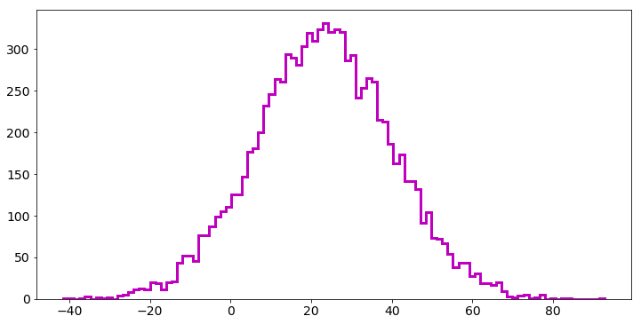

```python
fig, ax = pl.subplots(1,1,figsize=(12,6))
hh = ax.hist(n, bins=100, histtype='step', linewidth=3, color='m')
```

Here is a visualization of the uniformly distributed numbers in the array `r`:

```
(20, 500)
```

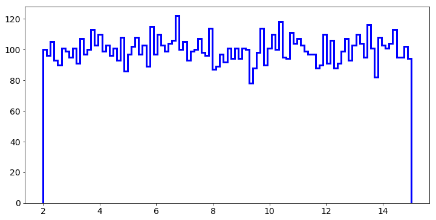

```python
fig, ax = pl.subplots(1,1,figsize=(12,6))
# note use of ravel method, which flattens multidimensional arrays
print(r.shape)
r_flat = r.ravel()
hh = ax.hist(r_flat, bins=100, histtype='step', lw=3, color='b')
```

And here is the array of random integers. In this case, we will play around with the size and location of the bins:

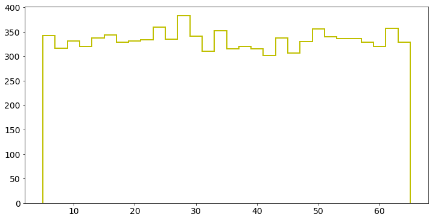

```python
fig, ax = pl.subplots(1,1,figsize=(12,6))
s_flat = s.ravel()
# note specification of bin array, rather than number of bins
int_bins = np.arange(start=lo_int, stop=hi_int+1, step=2)
# unequally spaced bins are possible, too
#int_bins = np.array([lo_int,10,25,hi_int])
hh = ax.hist(s_flat, bins=int_bins, histtype='step', lw=2, color='y')
```

### Some array methods

Arrays have a lot of methods, including some basic statistical functions:

```python
n.sum()
```

```
229546.22846416268
```

We can specify an axis along which we take the sum:

```python
r.sum(axis=1) # axis=0 sums across rows, axis=1 sums across columns, etc...
```

```
array([4352.88915519, 4275.61821399, 4239.9440771 , 4331.8890251 ,
       4230.57041786, 4247.68158581, 4227.98505474, 4109.41938885,
       4244.45193935, 4322.94417486, 4286.5440044 , 4341.55828319,
       4308.90496784, 4157.56237989, 4156.48774729, 4212.66478281,
       4200.81356028, 4302.30695781, 4151.4043752 , 4300.48781824])
```

We can get the mean of an array using the method `mean()` (which is just the numpy function `mean()`):

```python
# could also use np.mean(n)
n.mean()
```

```
22.954622846416267
```

We can specify the axis along which we calculate the mean, too:

```python
s.mean(axis=0)
```

```
array([35.245, 35.98 , 33.115, 37.145, 33.685, 34.775, 32.655, 36.77 ,
       34.385, 33.57 , 33.285, 35.34 , 34.41 , 33.345, 34.75 , 31.98 ,
       33.89 , 32.85 , 35.585, 33.32 , 34.56 , 34.89 , 35.305, 33.78 ,
       34.83 , 34.08 , 34.67 , 35.015, 34.095, 36.5  , 34.605, 33.94 ,
       34.445, 33.72 , 34.11 , 34.6  , 32.79 , 34.365, 34.54 , 33.02 ,
       35.08 , 34.335, 35.375, 35.135, 34.995, 34.72 , 34.475, 34.455,
       34.67 , 36.09 ])
```

Arrays also have a method for calculating the standard deviation and variance of the elements:

```python
n.std()
```

```
16.956979995090997
```

```python
n.var()
```

```
287.5391705539162
```

Arrays have a lot of methods (remember that you can hit tab after the dot to see the available methods). Some other useful methods are `max()`, `min()`, `argmax()`, `argmin()`.

```python
n.max() # largest value in n
```

```
92.73630770320565
```

```python
n.argmax() # index of largest value in n
```

```
8739
```

### A brief aside on linear algebra

In our initial discussion of operators, we saw the operator `@`, but we didn't use it. This is a new(-ish) operator in Python 3 that performs matrix multiplication. Matrix multiplication was possible before, it just required (slightly) more complicated (and (slightly) less intuitive and less easy to read) code to perform.

Because it may not be clear exactly what's going on here, and because this is actually a *programming* class, let's see how this works in Python.

First, we'll create a couple 2D arrays, one with random normal deviates in it, one with just ones:

```python
A = ones((1,5)) # array of ones
B = zeros((5,3)) # array of zeros
B[:,0] = normal(loc=0, scale=2, size=5) # fill in column 0 with normal variates with mean 0, SD 2
B[:,1] = normal(loc=2, scale=4, size=5) # fill in column 0 with normal variates with mean 2, SD 4
B[:,2] = normal(loc=-3, scale=8, size=5) # fill in column 0 with normal variates with mean -3, SD 8
```

Note that $\mathbf{A}$ is a $1 \times 5$ array.

```python
A
```

```
array([[1., 1., 1., 1., 1.]])
```

While $\mathbf{B}$ is a $5 \times 3$ array.

```python
B
```

```
array([[  0.97707905,   1.01632284,   1.62054943],
       [ -1.1673219 ,  -0.26774133,  -9.77654482],
       [  0.82841598,   1.02749529, -15.60779026],
       [ -0.35531221,  -1.42456215,   1.38852808],
       [ -0.67574747,   3.98031977, -17.13577869]])
```

Let's see what happens when we code the final line in the equation above explicitly for the first row of $\mathbf{A}$ and the second column of $\mathbf{B}$:

```python
A[0,0]*B[0,1] + A[0,1]*B[1,1] + A[0,2]*B[2,1] + A[0,3]*B[3,1] + A[0,4]*B[4,1]
```

```
4.331834415670764
```

We could also use the NumPy function `sum()` and exploit the fact that the operator `*` multiplies element-by-element when applied to vectors (which are just one dimensional arrays, or, mathematically speaking, 1-by-n or n-by-1 matrices):

```python
A[0,:]*B[:,1]
```

```
array([ 1.01632284, -0.26774133,  1.02749529, -1.42456215,  3.98031977])
```

```python
np.sum(A[0,:]*B[:,1])
```

```
4.331834415670764
```

Finally, we can also use `@` (and look at the element in the first row and second column) to get the same result:

```python
C = A @ B
C[0,1]
```

```
4.331834415670764
```

The `@` operater does this (very) quickly for every row in $\mathbf{A}$ and every column in $\mathbf{B}$, and it makes the code simpler and easier to read:

```python
C
```

```
array([[ -0.39288656,   4.33183442, -39.51103626]])
```

In this case, because we know how many rows there are, we could just plug that number in. But if the number of rows is unknown, we can use the `shape` method that arrays have to get it. The `shape` method returns a tuple:

```python
B.shape
```

```
(5, 3)
```

The number of rows is the first element, and the number of columns is the second. So, we can do this to get a vector containing the means of the columns of $\mathbf{B}$:

```python
nr = B.shape[0] # get the number of rows
C/nr # divide C by nr to get column means
```

```
array([[-0.07857731,  0.86636688, -7.90220725]])
```

As we saw above, arrays have a `mean` method built in, so we could have used that (and we can use it to verify that matrix multiplication is doing what we think it is doing). In this case, if we just call the `mean` method, it will give us the mean of the whole array:

```python
B.mean()
```

```
-2.371472560748852
```

As mentioned above, if we want the column means, we can specify the axis along which we want to calculate the mean. If we specify `axis=0`, the `mean` method will calculate the mean for each column (i.e., it will sum across the rows - the $0^{th}$ axis - recall that Python uses 0-indexing). If we specify `axis=1`, it will calculate the mean for each row (i.e., it will sum across the columns).

```python
B
```

```
array([[  0.97707905,   1.01632284,   1.62054943],
       [ -1.1673219 ,  -0.26774133,  -9.77654482],
       [  0.82841598,   1.02749529, -15.60779026],
       [ -0.35531221,  -1.42456215,   1.38852808],
       [ -0.67574747,   3.98031977, -17.13577869]])
```

```python
B.mean(axis=0)
```

```
array([-0.07857731,  0.86636688, -7.90220725])
```

```python
B.mean(axis=1)
```

```
array([ 1.20465044, -3.73720268, -4.58395967, -0.13044876, -4.61040213])
```

Also as mentioned above, we can caculate means and sums across higher dimensions if an array has them. Here are the "layer" means of `d`, the 3D array defined above (i.e., the means across the 3rd dimension, indexed by `axis=2`):

```python
d.mean(axis=2)
```

```
array([[ 2.,  7., 12., 17.],
       [22., 27., 32., 37.],
       [42., 47., 52., 57.]])
```

We will come back to linear algebra later in the semester.

### Vectorized functions

Many of the functions in NumPy and SciPy can take vectors (or larger arrays) as inputs, perform operations on the vectors (arrays), and return vectors (arrays) as outputs.

Consider the `pop` method that lists have. They operate on the list from which the method was called, and they return the final element (and remove it from the list):

```python
a = [1,2,3,4,5]
b = a.pop()
print("a is now",a,", while b is",b)
```

```
a is now [1, 2, 3, 4] , while b is 5
```

Or the function `len`, which takes a multi-element object and tells us how long it is:

```python
len(a)
```

```
4
```

#### A brief aside on arrays, scalars, and operators

We discussed basic arithmetic operators last week, illustrating their use with scalars (i.e., indvidual numbers). We can also use these operators with arrays or with operators and scalars together, but we need to be careful to understand how the shapes affect what the operators do.

If we want to add to arrays, element by element, the arrays need to have the same shape (with some exceptions, discussed below):

```python
X = arange(4)
Y = linspace(0,1,4)
print(X)
print(Y)
print(X+Y)
```

```
[0 1 2 3]
[0.         0.33333333 0.66666667 1.        ]
[0.         1.33333333 2.66666667 4.        ]
```

```python
Z = normal(size=5)
Y + Z
```

```
---------------------------------------------------------------------------
ValueError                                Traceback (most recent call last)
<ipython-input-58-18eac6880453> in <module>()
      1 Z = normal(size=5)
----> 2 Y + Z

ValueError: operands could not be broadcast together with shapes (4,) (5,)
```

The same issue applies if we want to multiply the two arrays element by element:

```python
X * Y
```

```
array([0.        , 0.33333333, 1.33333333, 3.        ])
```

```python
X * Z
```

```
---------------------------------------------------------------------------
ValueError                                Traceback (most recent call last)
<ipython-input-60-58ea3f4ce411> in <module>()
----> 1 X * Z

ValueError: operands could not be broadcast together with shapes (4,) (5,)
```

The constraint described above is an oversimplification, since NumPy will add and multiply arrays with different shapes if the shapes are "compatible". This is discuseed in the NumPy documention on [broadcasting](https://docs.scipy.org/doc/numpy-1.13.0/user/basics.broadcasting.html).

Here is an example of broadcasting with the 1D, length 4 array `X` defined above and a new $3 \times 4$ array `W`. Because `X` has four elements and `W` has three rows, each with four elements, NumPy broadcasts, adding `X` element-by-element within each row of `W`:

```python
W = arange(12).reshape((3,4))
```

```python
X
```

```
array([0, 1, 2, 3])
```

```python
W
```

```
array([[ 0,  1,  2,  3],
       [ 4,  5,  6,  7],
       [ 8,  9, 10, 11]])
```

```python
X + W
```

```
array([[ 0,  2,  4,  6],
       [ 4,  6,  8, 10],
       [ 8, 10, 12, 14]])
```

The same constraints apply to subtraction and division.

Finally, if you add, subtract, multiply, or divide a scalar and an array, the scalar is broadcast across all elements of the array:

```python
X
```

```
array([0, 1, 2, 3])
```

```python
2 + X
```

```
array([2, 3, 4, 5])
```

```python
2 - X
```

```
array([ 2,  1,  0, -1])
```

```python
2 * X
```

```
array([0, 2, 4, 6])
```

```python
X / 2
```

```
array([0. , 0.5, 1. , 1.5])
```

#### End brief aside

Contrast the functions `pop()` and `len()` with the NumPy function `cos()`, which takes a vector of [radian](https://en.wikipedia.org/wiki/Radian) values as input and returns a vector containing the cosine function values of each element of the input argument.

We will create an array of 1000 time values from 0 (inclusive) to 1 (exclusive) and then convert this to radians by multiplying by $2\pi$, using the NumPy builtin variable `pi` (we'll come back to radians and `cos()` and a number of related functions and issues later).

Here's the $\pi$ builtin variable:

```python
np.pi
```

```
3.141592653589793
```

```python
t = linspace(0,1,1000,endpoint=False) # start=0, end=1, num=1000, exclude the endpoint
f = np.cos(2*np.pi*3*t) # the input argument is array t multiplied by scalar 2*np.pi*3
print(t.shape, f.shape)
```

```
(1000,) (1000,)
```

```python
t[:5]
```

```
array([0.   , 0.001, 0.002, 0.003, 0.004])
```

```python
f[:5]
```

```
array([1.        , 0.99982235, 0.99928947, 0.99840155, 0.9971589 ])
```

The function `cos()` took our (scalar multiplied by an) array input and returned an array. We can do plot `f` to see what it looks like (the 3 in the input argument to `cos()` gives our sinusoid a frequency of 3 Hz):

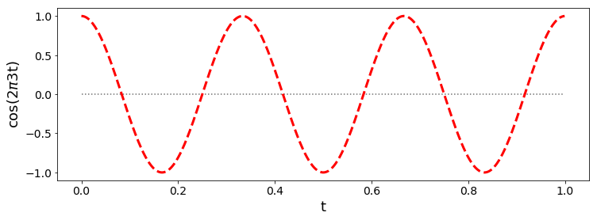

```python
alpha = [.75] # opacity parameter
gray = [.25,.25,.25] # RGB color specification
fig, ax = pl.subplots(1,1,figsize=(12,4)) # create figure and axis objects
ax.plot(t,zeros(len(t)),':',color=gray+alpha) # plot zero line for reference
ax.plot(t,f,'r--', linewidth=3) # plot f as a function of t, using a red dashed line (r--)
ax.set_xlabel('t',fontsize=18) # set x label
ax.set_ylabel('cos(2$\pi$3t)',fontsize=18); # set y label; semicolon supresses output
```

Many (perhaps most) NumPy functions operate on and return vectors. We can take the absolute value of our variable `f`, for example:

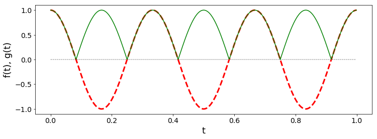

```python
g = np.abs(f) # absolute value
fig, ax = pl.subplots(1,1,figsize=(12,4))
ax.plot(t,zeros(len(t)),':',color=gray+alpha)
ax.plot(t,f,'r--',lw=3)
ax.plot(t,g,'g-',lw=1.5)
ax.set_xlabel('t',fontsize=18)
ax.set_ylabel('f(t), g(t)',fontsize=18);
```

We can scale `f` by multiplying it by a scalar:

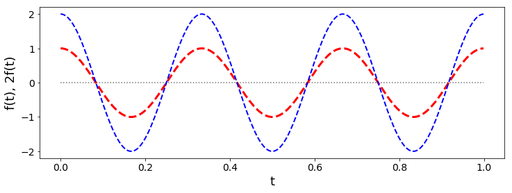

```python
fx2 = 2*f # double the amplitude of f
fig, ax = pl.subplots(1,1,figsize=(12,4))
ax.plot(t,zeros(len(t)),':',color=gray+alpha)
ax.plot(t,f,'r--',lw=3)
ax.plot(t,fx2,'b--',lw=2)
ax.set_xlabel('t',fontsize=18)
ax.set_ylabel('f(t), 2f(t)',fontsize=18);
```

As noted above, adding or subtracting arrays of the same size operates element-by-element.

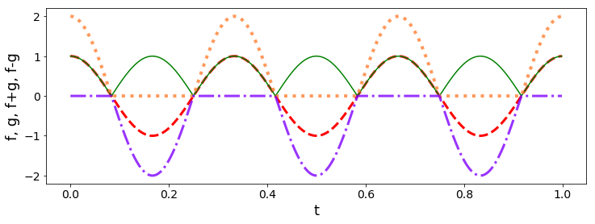

```python
fpg = f+g # f plus abs(f)
fmg = f-g # f minus abs(f)
fig, ax = pl.subplots(1,1,figsize=(12,4))
#ax.plot(t,zeros(len(t)),':',color=gray+alpha)
ax.plot(t,f,'r--',lw=3) # plot original function f
ax.plot(t,g,'g-',lw=1.5) # plot abs(f)
ax.plot(t,fpg,':',lw=4,color=[1,.5,.2,.8]) # plot f + abs(f) as orange dotted line
ax.plot(t,fmg,'-.',lw=3,color=[.5,0,1,.8]) # plot f - abs(f) as purple dash-dot line
ax.set_xlabel('t',fontsize=18)
ax.set_ylabel('f, g, f+g, f-g',fontsize=18);
```

As noted above, multiplication and division of arrays of the same size also operates element-by-element.

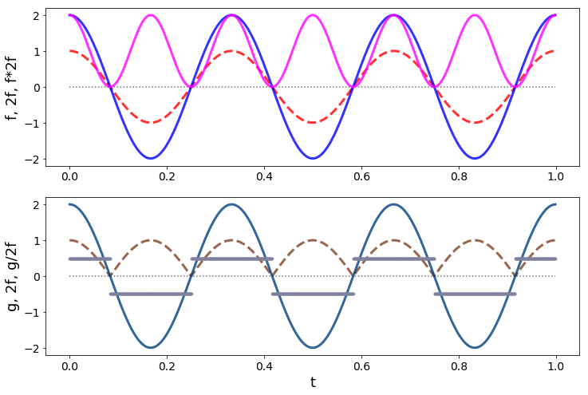

```python
ftfx2 = f*fx2 # f times 2f
gdfx2 = g/fx2 # abs(f) divided by 2f
fig, axes = pl.subplots(2,1,figsize=(12,8))
ax1, ax2 = axes
# first axis
ax1.plot(t,zeros(len(t)),':',color=gray+alpha)
ax1.plot(t,f,'--',lw=3, color=[1,0,0,.8]) # red
ax1.plot(t,fx2,'-',lw=3, color=[0,0,1,.8]) # blue
ax1.plot(t,ftfx2,'-',lw=3,color=[1,0,1,.8]) # f times 2f in purple
ax1.set_ylabel('f, 2f, f*2f',fontsize=18)
# second axis
ax2.plot(t,zeros(len(t)),':',color=gray+alpha)
ax2.plot(t,g,'--',lw=3, color=[.5,.25,.125,.8]) # abs(f) in brown
ax2.plot(t,fx2,'-',lw=3, color=[0,.25,.5,.8]) # 2f in blue
ax2.plot(t,gdfx2,'o',ms=3, color=[.5,.5,.625,.8]) # abs(f) divided by 2f in gray-blue
ax2.set_xlabel('t',fontsize=18)
ax2.set_ylabel('g, 2f, g/2f',fontsize=18);
```

## Introduction to logical (Boolean) indexing

We've talked about indexing, with lists, tuples, and arrays, and we've done so with numbers (integers, specifically). There is another very useful method for specifying (sub)sets of elements of arrays called logical indexing.

The basic idea of logical indexing is to use operators that return boolean variables to pick out elements that meet desired criteria.

So, for example, if you have a data set consisting of observations (e.g., test results of some sort) from children of different ages, and you want to just pick out the data for kids above a certain age, you can easily do so using logical indexing.

We can illustrate the basic idea with some of the variables we've already defined. Specifically, we can extract just the values of our `cos` function `f` that are greater than or equal to zero.

First, we use the `>=` operator to create a vector of `True` and `False` variables indicating where `f` is greater than or equal to 0 (and visualize a slice of f and of the Boolean array):

```python
fge0 = f >= 0 # booleans indicating when f is non-negative
fge0[75:95] # values around a point at which f goes from positive to negative
```

```
array([ True,  True,  True,  True,  True,  True,  True,  True,  True,
       False, False, False, False, False, False, False, False, False,
       False, False])
```

We can visualize the whole array of Booleans, noting that `True` maps to 1 and `False` to 0, plotting our Boolean array with `f`:

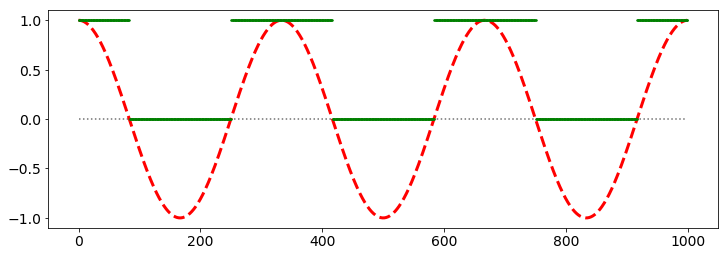

```python
fig, ax = pl.subplots(1,1,figsize=(12,4))
ax.plot(zeros(len(f)),':',color=gray+alpha)
ax.plot(f,'r--',lw=3)
ax.plot(fge0,'g.',ms=3);
```

We can then use our boolean array `fge0` to pick out all of the elements of `f` that are greater than or equal to zero. This is logical indexing.

```
(500,)
```

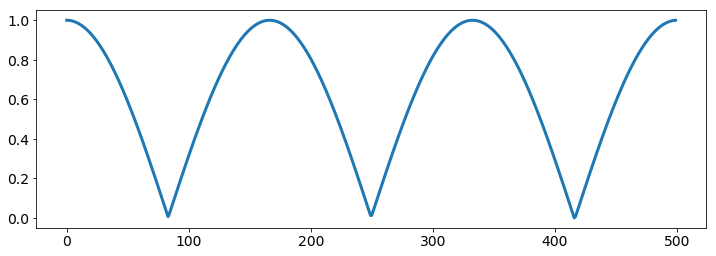

```python
fig, ax = pl.subplots(1,1,figsize=(12,4))
f_nn = f[fge0] # use logical indexing to pull out values of f that correspond to True in fge0
ax.plot(f_nn, linewidth=3)
f_nn.shape
```

Note that all of the elements of `f` that are less than zero are gone. Logical indexing pulls out whichever elements correspond to `True` values in the boolean array, dropping the elements that correspond to the `False` elements. Hence, `f_nn` is shorter than `f`.

To illustrate another example, let's take just the values from `f` that are greater than $\pm 0.35$:

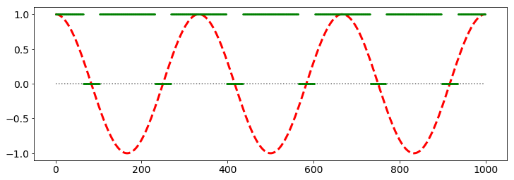

```python
fg35 = np.abs(f) >= .35 # True when abs(f) is greater than or equal to 0.35
fig, ax = pl.subplots(1,1,figsize=(12,4))
ax.plot(zeros(len(f)),':',color=gray+alpha)
ax.plot(f,'r--',lw=3)
ax.plot(fg35,'g.',ms=3);
```

```
(774,)
```

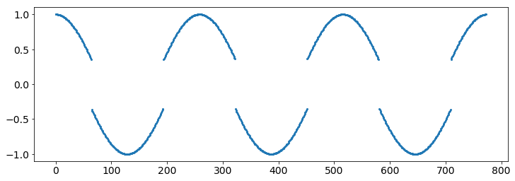

```python
fig, ax = pl.subplots(1,1,figsize=(12,4))
f_ss = f[fg35] # use logical indexing to pull out values of f that correspond to True in fg35
ax.plot(f_ss,'o',ms=2)
f_ss.shape
```

### Brief notes on SciPy

We've covered some basic uses of (parts of) NumPy and Matplotlib so far. SciPy is another very useful package (with a large number of component parts). We can peak into one tiny corner of SciPy by looking at (part of) the [`stats`](https://docs.scipy.org/doc/scipy/reference/tutorial/stats.html) module.

Specifically, we'll look at kernel density estimation (roughly, a method for getting a smoothed histogram). We will come back to look at kernal density estimation in more detail later.

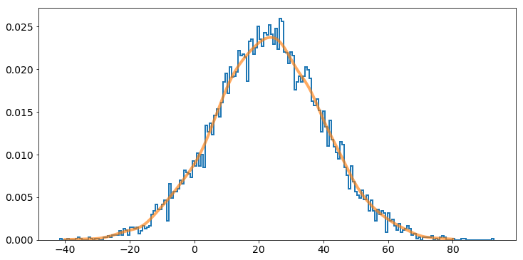

```python
from scipy.stats import gaussian_kde

kde_n = gaussian_kde(n,bw_method='silverman')

fig, ax = pl.subplots(1,1,figsize=(12,6))
hh = ax.hist(n,bins=200,histtype='step',lw=2,normed=True)
x_eval = linspace(-40,80,250)
ax.plot(x_eval,kde_n(x_eval),lw=4,alpha=.65);
```

### Extremely Brief Summary

Modules and packages provide easy-to-access reuseable code. NumPy, SciPy, and Matplotlib are extremely useful modules, with a large number of very useful functions for scientific research. We'll be using all three extensively throughout the semester, along with some other packages (e.g., Pandas, Scikit-Learn).

In addition, we talked about matrix multiplication using the `@` operator, broadcasting with other basic operators, and logical indexing. All three will come in handy at various points throughout the semester.